# Lab 08b: Bike rentals in DC

In this lab we will learn more about how to think about linear functions and how to build and evaluate linear models.

**LEARNING OBJECTIVES**

- Practice coding and recoding factor variables
- Practice transforming and centering continuous variables
- Review our exploratory data visualization skills
- Interpret different types of coefficients from linear models
- Fit and interpret models with multiple coefficients and interaction terms
- Compare linear models using AIC

Bike sharing systems are new generation of traditional bike rentals where whole process from membership, rental and return back has become automatic. Through these systems, a user is able to easily rent a bike from a particular position and return back at another position. Today, there exists great interest in these systems due to their important role in traffic, environmental and health issues.

Apart from interesting real world applications of bike sharing systems, the characteristics of data being generated by these systems make them attractive for the research. Opposed to other transport services such as bus or subway, the duration of travel, departure and arrival position is explicitly recorded in these systems. This feature turns bike sharing system into a virtual sensor network that can be used for sensing mobility in the city. Hence, it is expected that most of important events in the city could be detected via monitoring these data.

Source: [UCI Machine Learning Repository - Bike Sharing Dataset](http://archive.ics.uci.edu/ml/datasets/Bike+Sharing+Dataset)

# Getting started

Go to the course Posit Cloud Workspace and locate the assignment project for this module, which should be called `Assignments: Module 8b`.

First, open the R Markdown document `mod-lab-08b.Rmd` and Knit it.

Make sure it compiles without errors and you can preview the output within the Viewer Pane.

The output should also be automatically saved as an `.html` file with the same name.

## Packages

We’ll use the **tidyverse** package for much of the data wrangling and visualization and the data lives in the **dsbox** package. These packages are already installed for you. You can load them by running the following in your Console:

```r
library(tidyverse)
library(dsbox)
```

## Data

The data can be found in the **dsbox** package, and it’s called `dcbikeshare`. Since the dataset is distributed with the package, we don’t need to load it separately; it becomes available to us when we load the package. You can find out more about the dataset by inspecting its documentation, which you can access by running `?dcbikeshare` in the Console or using the Help menu in RStudio to search for `dcbikeshare`. You can also find this information [here](https://rstudio-education.github.io/dsbox/reference/dcbikeshare.html).

The data include daily bike rental counts (by members and casual users) of Capital Bikeshare in Washington, DC in 2011 and 2012 as well as weather information on these days. The original data sources are http://capitalbikeshare.com/system-data and http://www.freemeteo.com.

```r
data(dcbikeshare)
```

# Exercises

## Data Wrangling

Question 1

Recode the `season` variable to be a factor with meaningful level names as outlined in the codebook, with spring as the baseline level.

Question 2

Recode the `yr` variable to be a factor with levels 2011 and 2012, with 2011 as the baseline level.

Question 3

Recode the `weathersit` variable as 1 - clear, 2 - mist, 3 - light precipitation, and 4 - heavy precipitation, with clear as the baseline.

Weather can be an important factor in people’s transportation decisions. The temperature, feeling temperature, humidity, and windspeed variables have each been “normalized” by dividing the raw values by the maximum observed value. For our purposes, it would be better to work with the raw values.

Question 4

Look at the data codebook using `?dcbikeshare` and calculate raw temperature, feeling temperature, humidity, and windspeed as their values given in the dataset multiplied by the maximum raw values stated in the codebook for each variable. It’s fine to overwrite the original variables.

## Exploratory Data Analysis

Question 5

Recreate the following visualization, and interpret it in context of the data. **Hint:** You will need to use one of the variables you created above. The temperature plotted is the feeling temperature.

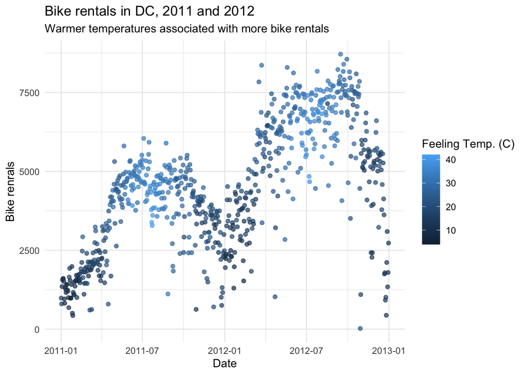

Question 6

Create an additional visualization displaying the relationship between bike rentals and season. There is more than one right answer, but think about what kind of plot would be most appropriate. Interpret the plot in context of the previous plot.

## Modeling

Now that we are acquainted with our data, we can begin creating and interpreting some models.

Question 7

Fit a linear model predicting total daily bike rentals from daily temperature. Write the linear model, interpret the slope and the intercept in context of the data, and determine and interpret the $R^2$.

Question 8

Fit another linear model predicting total daily bike rentals from daily feeling temperature. Write the linear model, interpret the slope and the intercept in context of the data, and determine and interpret the $R^2$. Is temperature or feeling temperature a better predictor of bike rentals? Explain your reasoning.

Question 9

Create a new centered daily feeling temperature predictor and fit a model predicting total daily bike rentals using your new variable. Compare this model to the previous in terms of its coefficients and $R^2$. What has changed? What has stayed the same? Explain what is going on.

Question 10

Fit a model predicting total daily bike rentals from season, year, whether the day is holiday or not, whether the day is a weekday (`workingday`) or not, the weather category, temperature, feeling temperature, humidity, and windspeed, as well as the interaction between feeling temperature and holiday. Compare this model with the better of the two prior models using AIC. Which model seems best?

As our models get larger, our `summary` display can get unweildy. In these cases, the `tidy` function from the `broom` package can help us out. We can use this function to transform our model into a tibble summarizing its coefficients. Then we can use all our standard data wrangling and plotting skills on that!

Question 11

Use the `broom::tidy()` function to extract the model’s coefficients. Create a pointrange plot centered on each coefficients’ `estimate` and using errorbars that are two times the `std.error`. To help keep the coefficient terms readable, try swapping the axes of our plot using `coord_flip()`. (Hint: you will have to calculate the `ymin` and `ymax` manually before plotting.)

Question 12

Using the coefficients of the previous model, calculate the slope of feeling temperature for holidays and non-holidays and interpret both values.

Now go back through your write up to make sure you’ve answered all questions and all of your R chunks are properly labelled.

**SUBMITTING YOUR WORK**

Once you decide as a team that you’re done with this lab, change the YAML `output` from `html_output` to `pdf_output.` Now knit the document to produce a final PDF file. Make sure all team members have access to the PDF and each person needs to upload the PDF as a Canvas assignment.